# Module_4_Logistic

Rahul Jadhav

2/8/2022

```r
main_dataset <- read.csv("AmesHousing.csv")

##Creating subset of relevant continuous variable
cleaned_dataset <- main_dataset[sapply(main_dataset, is.integer) | sapply(main_dataset, is.numeric) ]
cleaned_dataset <- cleaned_dataset %>%
  dplyr::select(-c(ï..Order,
                    PID,
                    Year.Remod.Add,
                    Garage.Yr.Blt,
                    Mo.Sold,
                    Yr.Sold
                    ))
```

## INTRODUCTION

In this assignment we are going to perform logistic Regression in Ames Dataset. In Machine Learning, Logistic Regression is commonly used to address categorization issues. When the answer response is a binary(1 and 0 )or 2 level factor variable such as yes or no, Male or Female, etc. and can be converted into binary, Logistic Regression is used.

The way Logistic regression differs from linear regression is, in linear regression you can use continuous variable and in Logistic regression you use Binary variable as your response variable. Also, A straight line is the best fit line in linear regression, and an S-shaped line, sometimes known as a “Squiggle,” is the best fit line in logistic regression.

The coefficient of logistic regression can interpreted using 3 scales, Probability scale, Odds Scale and Log Odds Scale.

## SUMMARY TABLE

```r
psych::describe(cleaned_dataset) %>%
  dplyr::select(count = n,
         Mean = mean,
         Median = median,
         Standard_Deviation = sd,
         )%>%
  mutate(
    Coefficient_Variation = Standard_Deviation/Mean
  )
```

```
##                 count      Mean   Median Standard_Deviation
## MS.SubClass      2930     57.39     50.0              42.64
## Lot.Frontage     2440     69.22     68.0              23.37
## Lot.Area         2930  10147.92   9436.5            7880.02
## Overall.Qual     2930      6.09      6.0               1.41
## Overall.Cond     2930      5.56      5.0               1.11
## Year.Built       2930   1971.36   1973.0              30.25
## Mas.Vnr.Area     2907    101.90      0.0             179.11
## BsmtFin.SF.1     2929    442.63    370.0             455.59
## BsmtFin.SF.2     2929     49.72      0.0             169.17
## Bsmt.Unf.SF      2929    559.26    466.0             439.49
## Total.Bsmt.SF    2929   1051.61    990.0             440.62
## X1st.Flr.SF      2930   1159.56   1084.0             391.89
## X2nd.Flr.SF      2930    335.46      0.0             428.40
## Low.Qual.Fin.SF  2930      4.68      0.0              46.31
## Gr.Liv.Area      2930   1499.69   1442.0             505.51
## Bsmt.Full.Bath   2928      0.43      0.0               0.52
## Bsmt.Half.Bath   2928      0.06      0.0               0.25
## Full.Bath        2930      1.57      2.0               0.55
## Half.Bath        2930      0.38      0.0               0.50
## Bedroom.AbvGr    2930      2.85      3.0               0.83
## Kitchen.AbvGr    2930      1.04      1.0               0.21
## TotRms.AbvGrd    2930      6.44      6.0               1.57
## Fireplaces       2930      0.60      1.0               0.65
## Garage.Cars      2929      1.77      2.0               0.76
## Garage.Area      2929    472.82    480.0             215.05
## Wood.Deck.SF     2930     93.75      0.0             126.36
## Open.Porch.SF    2930     47.53     27.0              67.48
## Enclosed.Porch   2930     23.01      0.0              64.14
## X3Ssn.Porch      2930      2.59      0.0              25.14
## Screen.Porch     2930     16.00      0.0              56.09
## Pool.Area        2930      2.24      0.0              35.60
## Misc.Val         2930     50.64      0.0             566.34
## SalePrice        2930 180796.06 160000.0           79886.69
##                 Coefficient_Variation
## MS.SubClass                      0.74
## Lot.Frontage                     0.34
## Lot.Area                         0.78
## Overall.Qual                     0.23
## Overall.Cond                     0.20
```

[output cut: 13 more lines]

```
## Half.Bath                        1.32
## Bedroom.AbvGr                    0.29
## Kitchen.AbvGr                    0.20
## TotRms.AbvGrd                    0.24
## Fireplaces                       1.08
## Garage.Cars                      0.43
## Garage.Area                      0.45
## Wood.Deck.SF                     1.35
## Open.Porch.SF                    1.42
## Enclosed.Porch                   2.79
## X3Ssn.Porch                      9.70
## Screen.Porch                     3.51
## Pool.Area                       15.87
## Misc.Val                        11.18
## SalePrice                        0.44
```

## PREPARING DATASET

For logistic regression we will convert selling price of the house into 1 and 0. For making it more sensible we will create a new variable called binary_sp and if the selling price is above 200,000 as 1 and 0 if selling price is lesser than 200,000.

```r
sapply(cleaned_dataset, function(x) sum(is.na(x)))
```

```
##     MS.SubClass    Lot.Frontage        Lot.Area    Overall.Qual    Overall.Cond
##               0             490               0               0               0
##      Year.Built    Mas.Vnr.Area    BsmtFin.SF.1    BsmtFin.SF.2     Bsmt.Unf.SF
##               0              23               1               1               1
##   Total.Bsmt.SF     X1st.Flr.SF     X2nd.Flr.SF Low.Qual.Fin.SF     Gr.Liv.Area
##               1               0               0               0               0
##  Bsmt.Full.Bath  Bsmt.Half.Bath       Full.Bath       Half.Bath   Bedroom.AbvGr
##               2               2               0               0               0
##   Kitchen.AbvGr   TotRms.AbvGrd      Fireplaces     Garage.Cars     Garage.Area
##               0               0               0               1               1
##    Wood.Deck.SF   Open.Porch.SF  Enclosed.Porch     X3Ssn.Porch    Screen.Porch
##               0               0               0               0               0
##       Pool.Area        Misc.Val       SalePrice
##               0               0               0
```

```r
cleaned_dataset$binary_sp <- ifelse(cleaned_dataset$SalePrice > 200000,1,0)
table(cleaned_dataset$binary_sp)
```

```
##
##    0    1
## 2073  857
```

## DEVELOPING MODEL AND ITS INTERPRETATION

```r
Model1 <- glm(binary_sp ~ Overall.Qual +
                Gr.Liv.Area +
                Year.Built +
                Fireplaces , data= cleaned_dataset , family = "binomial")
summary(Model1)
```

```
##
## Call:
## glm(formula = binary_sp ~ Overall.Qual + Gr.Liv.Area + Year.Built +
##     Fireplaces, family = "binomial", data = cleaned_dataset)
##
## Deviance Residuals:
##     Min       1Q   Median       3Q      Max
## -6.3336  -0.2799  -0.0707   0.1274   3.1096
##
## Coefficients:
##                Estimate Std. Error z value Pr(>|z|)
## (Intercept)  -7.994e+01  6.500e+00 -12.298  < 2e-16 ***
## Overall.Qual  1.344e+00  9.061e-02  14.828  < 2e-16 ***
## Gr.Liv.Area   3.344e-03  2.229e-04  15.006  < 2e-16 ***
## Year.Built    3.238e-02  3.271e-03   9.897  < 2e-16 ***
## Fireplaces    8.931e-01  1.143e-01   7.815 5.51e-15 ***
## ---
## Signif. codes:  0 '***' 0.001 '**' 0.01 '*' 0.05 '.' 0.1 ' ' 1
##
## (Dispersion parameter for binomial family taken to be 1)
##
##     Null deviance: 3541.6  on 2929  degrees of freedom
## Residual deviance: 1375.4  on 2925  degrees of freedom
## AIC: 1385.4
##
## Number of Fisher Scoring iterations: 7
```

```r
exp(coef(Model1))
```

```
##  (Intercept) Overall.Qual  Gr.Liv.Area   Year.Built   Fireplaces
## 1.916463e-35 3.832617e+00 1.003350e+00 1.032907e+00 2.442728e+00
```

```r
coef_Model1 <-stargazer(Model1,odd.ratio = TRUE ,type = "text")
```

```
  =============================================
                        Dependent variable:
                    ---------------------------
                             binary_sp
  ---------------------------------------------
  Overall.Qual               1.344***
                              (0.091)

  Gr.Liv.Area                0.003***
                             (0.0002)

  Year.Built                 0.032***
                              (0.003)

  Fireplaces                 0.893***
                              (0.114)

  Constant                  -79.940***
                              (6.500)

  ---------------------------------------------
  Observations                 2,930
  Log Likelihood             -687.680
  Akaike Inf. Crit.          1,385.359
  =============================================
  Note:             *p<0.1; **p<0.05; ***p<0.01

  ====
  TRUE
  ----
```

### Augmented Logistic Regression Model:

```r
augment_model1<- augment(Model1, type.predict = "response") %>%
  mutate(.fitted = round(.fitted, 3), .resid = round(.resid, 3),
         .hat=round(.hat, 3), .cooksd = round(.cooksd, 3),
         price_hat = round(.fitted))%>%
  dplyr::select(c("binary_sp", ".fitted", ".resid", "price_hat"))
augment_model1
```

```
  # A tibble: 2,930 x 4
     binary_sp .fitted .resid price_hat
         <dbl>   <dbl>  <dbl>     <dbl>
   1         1   0.251  1.66          0
   2         0   0.001 -0.049         0
   3         0   0.017 -0.187         0
   4         1   0.884  0.498         1
   5         0   0.098 -0.453         0
   6         0   0.283 -0.815         0
   7         1   0.518  1.15          1
   8         0   0.398 -1.01          0
   9         1   0.845  0.58          1
  10         0   0.753 -1.67          1
  # ... with 2,920 more rows
```

Broom package provides us with a function called Augment. Augment function provides us with important information about our model like the Fitted Value , residual value and price_hat

## Visualization :

### SalePrice and Overall Quality of House:

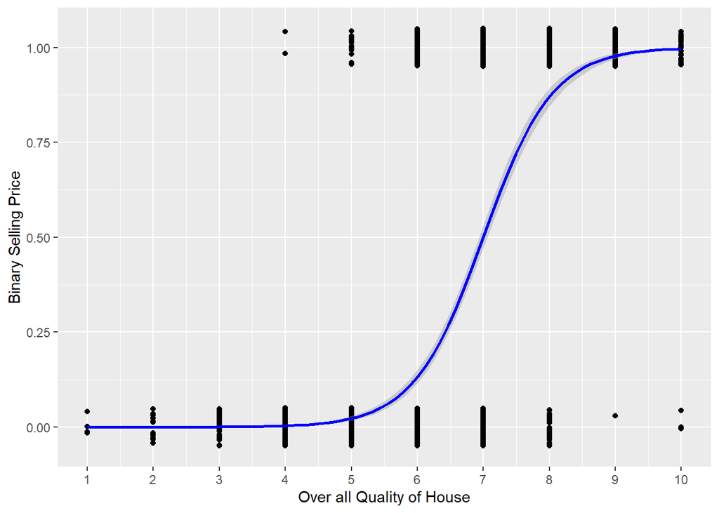

```r
ggplot(cleaned_dataset, aes(x= Overall.Qual, y=binary_sp))+
  geom_jitter(width = 0, height = 0.05)+
  scale_x_continuous(breaks = 1:10)+
  geom_smooth(method = "glm", method.args = list(family="binomial"), color = "blue")+
  xlab("Over all Quality of House")+
  ylab("Binary Selling Price")
```

S-shaped line helps us to determine th changing trend of the probability of scale of 0 and 1 with 1 unit change in the predictor variables. From the Above plot we can see that the Selling Price of the house is 200000 dollar if the quality of the house is above 7.

### SalePrice and General Living Area

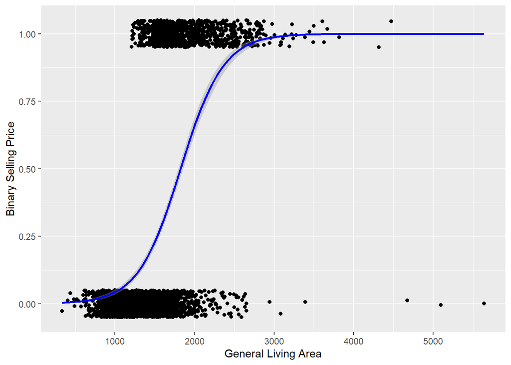

```r
ggplot(cleaned_dataset, aes(x= Gr.Liv.Area, y=binary_sp))+
  geom_jitter(width = 0, height = 0.05)+
  geom_smooth(method = "glm", method.args = list(family="binomial"), color = "blue")+
  xlab("General Living Area")+
  ylab("Binary Selling Price")
```

From the Above plot we can see that the Selling Price of the house is 200000 dollar if the General Living Area is Above 2000 sq feet.

### SalePrice and Year of built

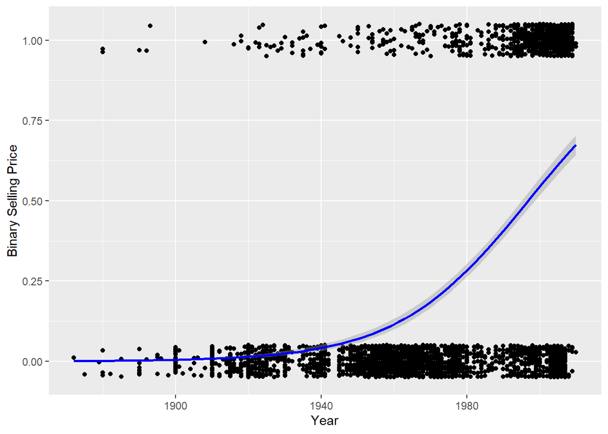

```r
ggplot(cleaned_dataset, aes(x= Year.Built, y=binary_sp))+
  geom_jitter(width = 0, height = 0.05)+
  geom_smooth(method = "glm", method.args = list(family="binomial"), color = "blue")+
  xlab("Year")+
  ylab("Binary Selling Price")
```

### SalePrice and No of fire Places in the house

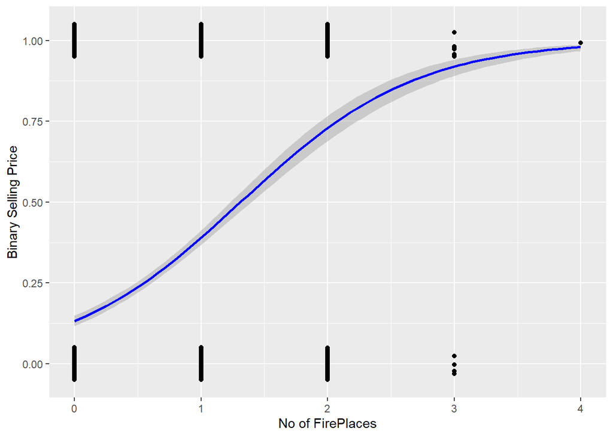

```r
ggplot(cleaned_dataset, aes(x= Fireplaces, y=binary_sp))+
  geom_jitter(width = 0, height = 0.05)+
  geom_smooth(method = "glm", method.args = list(family="binomial"), color = "blue")+
  xlab("No of FirePlaces")+
  ylab("Binary Selling Price")
```

### Effect Plots

The effect plots show us how predicted probabilities change when we change our independent variables.

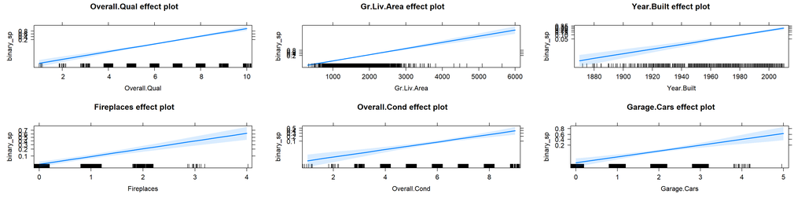

```r
Model2 <- glm(binary_sp ~ Overall.Qual +
                Gr.Liv.Area +
                Year.Built +
                Fireplaces +
                Overall.Cond+
                Garage.Cars

                , data= cleaned_dataset , family = "binomial")
plot(allEffects(Model2))
```

## References:

- Multiple and Logistic Regression in R [DataCamp]
- StatQuest: Logistic Regression. (2018, March 5). YouTube. https://www.youtube.com/watch?v=yIYKR4sgzI8&list=PLblh5JKOoLUKxzEP5HA2d-Li7IJkHfXSe